# South Orange-Maplewood School District — NJ School Data Almanac – NJ District Profiles

NJ School Data Almanac

South Orange-Maplewood School District

ESSEX COUNTY · TRADITIONAL PUBLIC DISTRICT · DFG I · 6,865 STUDENTS (2026)

6,865

Students

93.2%

4-yr grad rate

68.9%

Gr 3-8 ELA

11.2%

Chronically absent

$18,952

Per pupil

*10 things the data says about South Orange-Maplewood School District. Every figure is computed from New Jersey Department of Education data via the njschooldata package — nothing is estimated. Comparisons use District Factor Group (DFG) peers (103 districts in DFG I).*

No. 1 DEMOGRAPHICS

## South Orange-Maplewood’s Black Enrollment Share Has Fallen From 35.5% to 21% Since 2015

A district known nationally for its integration efforts has seen its largest single demographic shift among Black students, even as total enrollment held flat.

South Orange-Maplewood has built much of its public identity around racial integration, which makes the past decade of demographic data striking. In 2015, students who are Black made up 35.5% of enrollment. By 2026 that share had fallen to 21.0%, a drop of 14.5 percentage points and the single largest demographic change in the district over the period.

The shift is not explained by a shrinking district. Total enrollment in 2026 stands at 6,865 students, essentially unchanged from 6,858 in 2015, a net change of just 7 students (0.1%). Other groups grew over the same window: the share of students who are multiracial rose 6.2 points and the share of students who are Hispanic rose 4.7 points, climbing from 6.6% to 11.3%. The share of students who are white moved from 50.3% to 54.3%.

What the enrollment tables cannot tell us is where Black families went, or why, within a community that markets itself on diversity. Are these households leaving the district’s public schools, leaving the towns entirely, or being reshaped by the rise in multiracial identification? That is the question the next board and superintendent inherit.

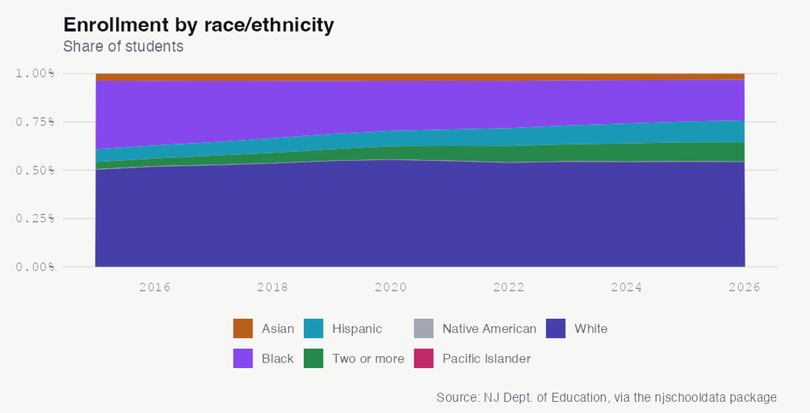

See the underlying data ›

No. 2 EQUITY

## In Grades 3-8 Reading, South Orange-Maplewood’s Black Students Pass at 45% and Asian Students at 88%

The district’s 2024 elementary and middle-school reading scores split sharply by race, income and language, well before high school graduation.

Income and language sort the results even more sharply. Students who are economically disadvantaged passed at 36.5%, against 73.7% for their peers who are not, a 37.2-point gap. Students with disabilities passed at 26.8% and multilingual learners at 18.2%. The districtwide rate, 68.9%, sits well above most of these subgroups precisely because it averages them together.

These are the grades where reading habits and confidence are set. The data cannot say why a Black third- through eighth-grader in this district is so much less likely to read proficiently than a white or Asian classmate down the hall, but it shows the gap is present years before the diplomas are counted.

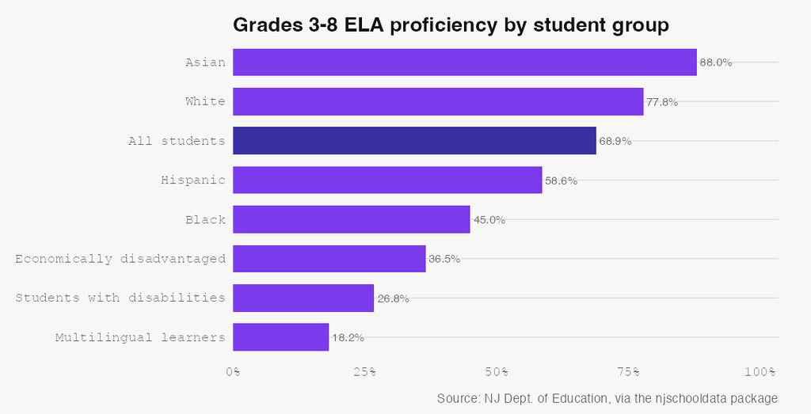

See the underlying data ›

No. 3 ACHIEVEMENT

## Five Years On, South Orange-Maplewood’s Grade 3-8 Math Scores Still Trail Their Pre-COVID Mark

Elementary and middle-school reading has fully recovered, but math proficiency in grades 3-8 remains below where it stood in 2019.

South Orange-Maplewood’s recovery from pandemic learning loss has been uneven across subjects. In grades 3 through 8, NJSLA reading proficiency dipped only modestly, from 68.8% in 2019 to 65.2% in 2022, and by 2024 had climbed back to 68.9%, essentially matching its pre-pandemic level.

Math tells a harder story. Proficiency in grades 3-8 fell from 56.1% in 2019 to 46.9% in 2022, a 9.2-point drop, and has recovered only partway since, reaching 49.9% in 2023 and 52.7% in 2024. Five years after the pre-COVID baseline, the district’s elementary and middle-school math proficiency remains 3.4 points below where it started, even as reading has returned to form.

The split matters because math gaps compound: students who fall behind in middle-school math have a steeper climb through high-school sequences. The data raises a question the recovery so far leaves open, namely whether 2024’s gains are the front edge of a full rebound or a plateau short of the 2019 mark.

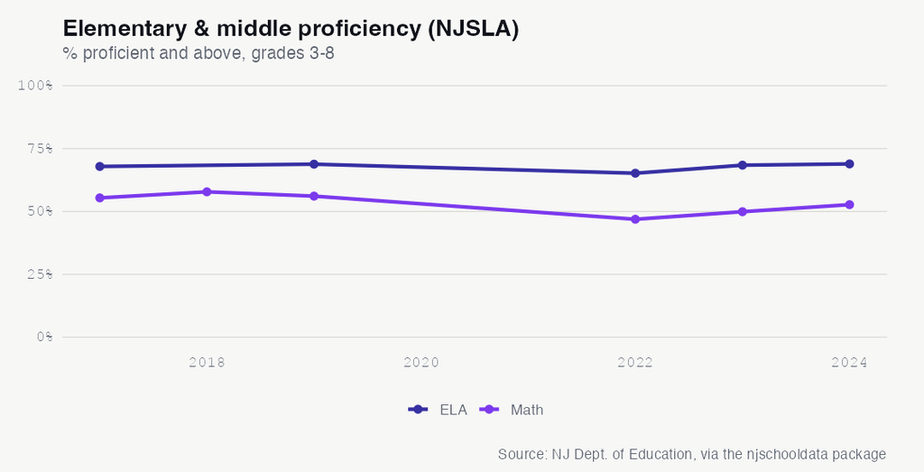

See the underlying data ›

No. 4 GRADUATION

## A 13-Point Graduation Gap: White Students Finish at 98% in South Orange-Maplewood, Black Students at 85%

Asian, multiracial and white students graduate at or near 100%, while Black, Hispanic and students with disabilities trail well behind.

South Orange-Maplewood graduates nearly all of some of its students. In the class of 2025, students who are Asian graduated at 100%, students who are multiracial at 100%, and students who are white at 98.0%. Those are rates most districts would envy.

The same year tells a second story. Students who are Black graduated at 84.9%, students who are Hispanic at 86.1%, and students who are economically disadvantaged at 86.3%. Students with disabilities posted the lowest rate at 81.0%, with multilingual learners close behind at 84.6%. The gap between students who are white (98.0%) and students who are Black (84.9%) is 13.1 percentage points within a single building system serving the same two towns.

The overall district rate of 93.2% sits between these poles, a figure that can flatter or conceal depending on which students it is averaged across. With a Black cohort of 152 students and a white cohort of 255, the gap is not a rounding artifact of small numbers. The data raises a question it cannot answer: what happens in the four years before graduation that sends students out the door at such different rates?

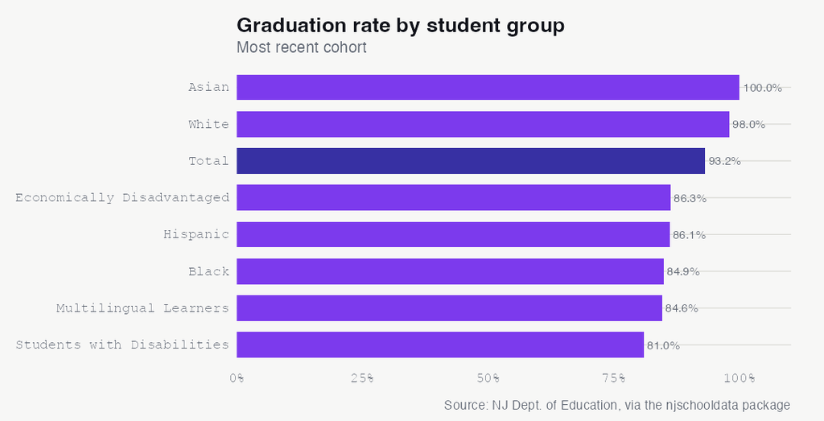

See the underlying data ›

No. 5 GRADUATION

## South Orange-Maplewood’s 93% Graduation Rate Ranks in the 7th Percentile Among Its 103 Peers

A rate that sounds strong on its own falls near the bottom when measured against similarly advantaged districts.

A 93.2% four-year graduation rate, the district’s mark for 2025, reads as a success in isolation. Measured against South Orange-Maplewood’s peers, it reads differently: that rate places the district in just the 7th percentile among the 103 districts in its District Factor Group, where the peer median is 97.0%.

The district’s own recent history shows volatility rather than steady strength. The rate was 91.8% in 2020, dipped to 88.6% in 2024, then rebounded to 93.2% in 2025, the high point of the six years on record. Even at that high point, nearly four percentage points separate the district from the typical peer.

For a community in one of the state’s most advantaged socioeconomic bands, the relative position is the surprise. The numbers leave open the question of whether the 2025 rebound is the start of a climb toward the peer median, or another swing in a six-year pattern that has yet to settle.

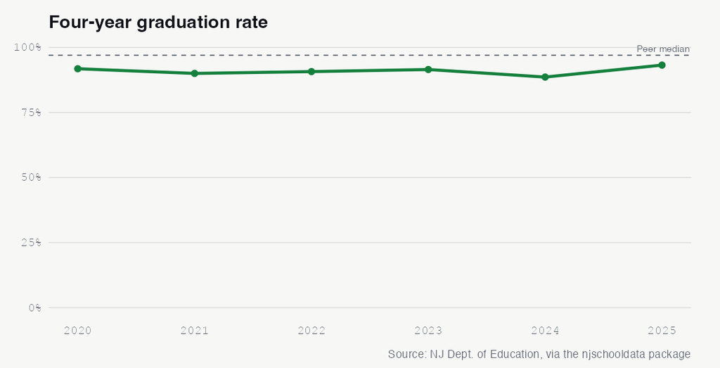

See the underlying data ›

No. 6 ATTENDANCE

## Chronic Absenteeism Hit 11.2% in South Orange-Maplewood, Above the 7.8% Peer Median

Even after recovering from a pandemic peak, the share of students missing significant school time runs well above comparable districts.

The good news in South Orange-Maplewood’s attendance data is that the worst appears to be over. The share of students who were chronically absent surged from 8.5% in 2019 to a peak of 15.6% in 2023, then fell to 11.2% in 2024. The recovery is real.

The harder news is the comparison. That 11.2% figure still sits well above the peer median of 7.8% for the district’s DFG I group, and it remains above the district’s own pre-pandemic baseline of 8.5% in 2019. In other words, attendance has improved from crisis levels but has not returned to where it was, and it lags the districts South Orange-Maplewood most resembles.

Chronic absenteeism is one of the earliest warning signs for the achievement and graduation gaps that show up later in this data. The figures cannot say which students are missing the most school, but they raise the question of whether the path back to the 2019 baseline runs through the same student groups scoring and graduating at lower rates today.

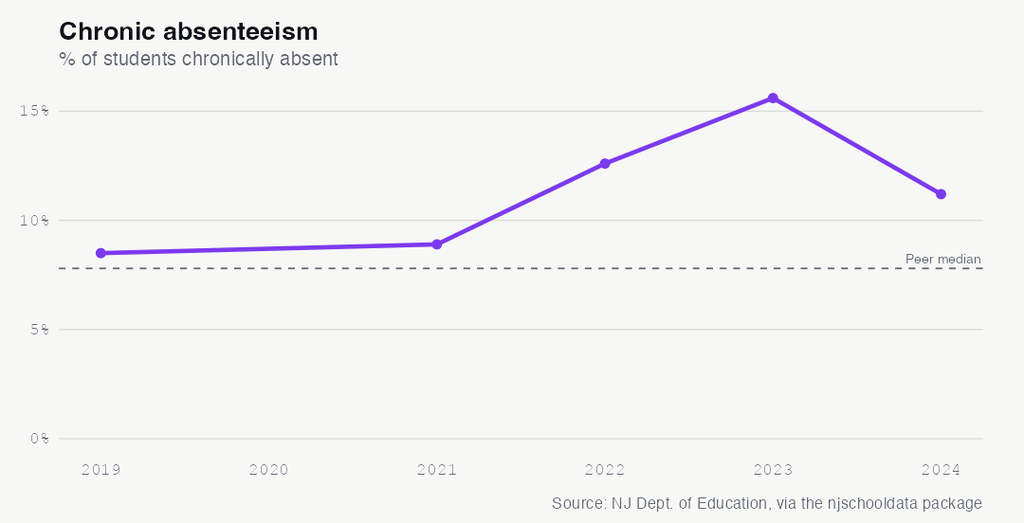

See the underlying data ›

No. 7 FINANCE

## South Orange-Maplewood Spends $18,952 Per Pupil, Below the Peer Median Among 103 Affluent Districts

Despite sitting in one of the state’s most advantaged District Factor Groups, the district spends less per student than most of its peers.

South Orange-Maplewood belongs to District Factor Group I, the second-highest of New Jersey’s socioeconomic bands, alongside 103 peer districts. On per-pupil spending, however, the district lands in the bottom third. Its 2024 per-pupil figure of $18,952 ranks at the 32nd percentile among DFG I peers, below the peer median of $20,613, a difference of roughly $1,661 per student.

This is not because spending has stagnated. Per-pupil spending has climbed 31.6% since 2014, when it stood at $14,397. But the district’s rank among similarly affluent communities tells a relative story: it spent more competitively in the late 2010s, ranking as high as 22nd in 2019, and has since slipped to 49th in 2024.

For families in two towns known for high property values and strong civic engagement, the data poses a pointed question: in a peer group of well-resourced districts, why does South Orange-Maplewood spend less per child than most, and is that a choice or a constraint?

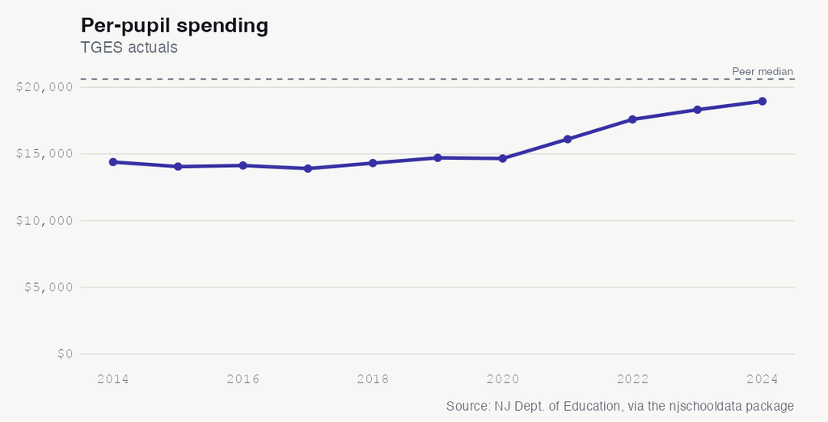

See the underlying data ›

No. 8 DEMOGRAPHICS

## South Orange-Maplewood’s Hispanic and Multilingual Enrollment Climbed as Black Share Fell

The same decade that saw South Orange-Maplewood’s Black enrollment share contract also saw several groups expand. The share of students who are Hispanic rose from 6.6% in 2015 to 11.3% in 2026, a gain of 4.7 percentage points and a near-doubling. The share of students who are multiracial climbed even faster in relative terms, from 3.7% to 10.0%, a 6.2-point increase that is the largest gain of any group.

The English-learner and lunch-assistance data point the same direction. Students classified as multilingual learners grew from 81 in 2015 to 151 in 2026, nearly doubling the count even as total enrollment held flat. Participation in free or reduced-price lunch, which had fallen from 1,401 students in 2015 to a low of 767 in 2022, has since rebounded to 1,043 in 2026.

Taken together, these trends describe a student body whose composition is shifting on several axes at once. The question for a district that defines itself by diversity is whether its programs, from language support to advanced coursework, are following the students it now serves.

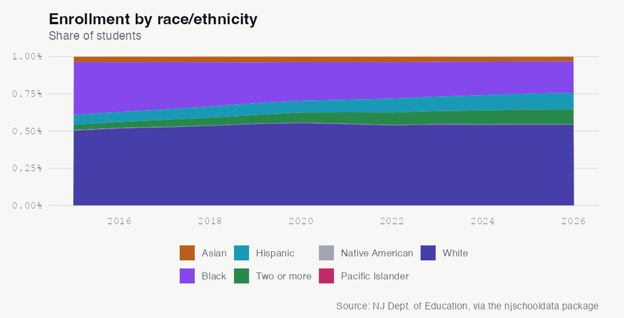

See the underlying data ›

No. 9 COLLEGE READINESS

## 55% of South Orange-Maplewood Students Pass an AP or IB Exam, More Than Double the State’s 23%

The district’s advanced-course success rate jumped in 2024 to its highest level in years, far outpacing New Jersey overall.

On one measure of advanced academic achievement, South Orange-Maplewood stands well above the rest of New Jersey. In 2024, 55.1% of students scored a 3 or higher on an AP exam or a 4 or higher on an IB exam, compared with 23.0% statewide, a gap of more than two to one in the district’s favor.

The 2024 figure also marks a rebound. The share scoring 3+/4+ had dipped to 40.3% in 2021, the pandemic’s deepest year, before climbing back through 44.1% in 2022 and 43.9% in 2023. The 55.1% mark in 2024 is the highest in the seven years of data. Participation rose alongside success: 67.1% of students took AP or IB coursework in 2024, up from 56% in 2019.

The district clearly runs a strong advanced-course pipeline. The open question, read against the achievement and graduation gaps elsewhere in this data, is who is sitting in those AP and IB seats, and whether the students excelling on these exams reflect the full diversity of the district.

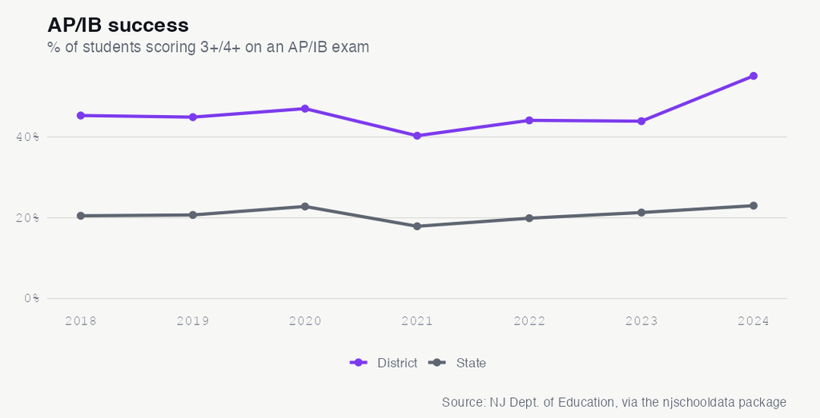

See the underlying data ›

No. 10 ENROLLMENT

## South Orange-Maplewood Lost 431 Students During COVID, a 6% Drop It Has Only Partly Reversed

Enrollment fell from a 2020 peak through the pandemic and has since clawed back, but 2026 remains below where it stood before.

South Orange-Maplewood entered the pandemic at its enrollment high. The district counted 7,148 students in 2020, the peak of a steady climb from 6,858 in 2015. Then came the drop: enrollment fell to 6,860 in 2021 and 6,672 in 2022, a two-year loss of 431 students, or 6.1%, measured from 2019.

The recovery has been real but incomplete. After holding flat at 6,672 in 2023, enrollment rebounded to 6,891 in 2024 and 6,990 in 2025, before slipping again to 6,865 in 2026. That latest figure sits below the 2020 peak of 7,148 and essentially level with the 2015 starting point.

The arc is familiar across New Jersey districts, but the question it raises here is local: is the 2026 dip after two years of growth a one-year wobble, or a sign that South Orange-Maplewood’s enrollment has found a new, lower ceiling than the one it hit in 2020?

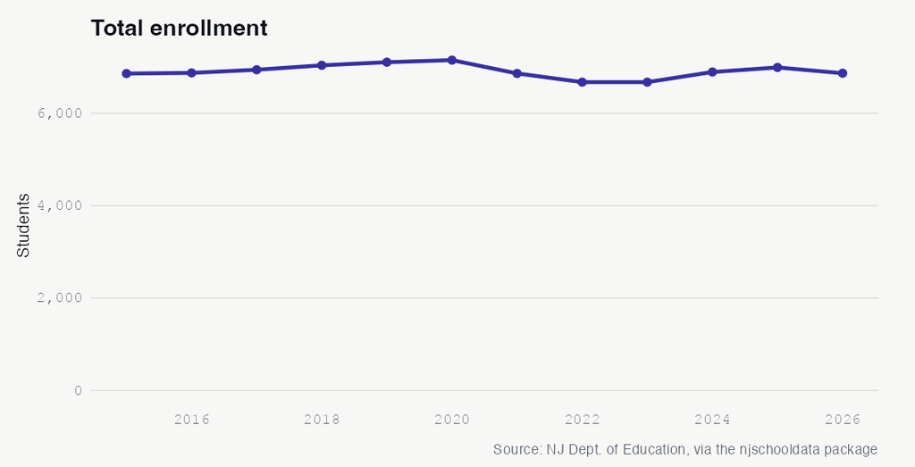

See the underlying data ›

## The Almanac

The full longitudinal record behind the stories above. Every number a reader can check.

### Enrollment (total)

| year | students | yoy | yoy_pct |
| --- | --- | --- | --- |
| 2015 | 6858 | NA | NA |
| 2016 | 6872 | 14 | 0.2 |
| 2017 | 6940 | 68 | 1 |
| 2018 | 7036 | 96 | 1.4 |
| 2019 | 7103 | 67 | 1 |
| 2020 | 7148 | 45 | 0.6 |
| 2021 | 6860 | -288 | -4 |
| 2022 | 6672 | -188 | -2.7 |
| 2023 | 6672 | 0 | 0 |
| 2024 | 6891 | 219 | 3.3 |
| 2025 | 6990 | 99 | 1.4 |
| 2026 | 6865 | -125 | -1.8 |

### Demographic share (%) by year

| end_year | white | black | hispanic | asian | native_american | pacific_islander | multiracial |
| --- | --- | --- | --- | --- | --- | --- | --- |
| 2015 | 50.3 | 35.5 | 6.6 | 3.7 | 0.2 | 0.1 | 3.7 |
| 2016 | 51.8 | 33.3 | 6.8 | 3.8 | 0.1 | 0.1 | 4 |
| 2017 | 52.6 | 31.7 | 7 | 3.7 | 0.1 | 0.1 | 4.8 |
| 2018 | 53.5 | 29.6 | 7.6 | 3.8 | 0.1 | 0.1 | 5.3 |
| 2019 | 54.8 | 27.4 | 7.9 | 3.9 | 0.1 | 0.1 | 5.9 |
| 2020 | 55.4 | 25.9 | 7.9 | 3.7 | 0.1 | 0.1 | 6.9 |
| 2021 | 54.7 | 25.2 | 8.5 | 3.7 | 0.1 | 0.1 | 7.6 |
| 2022 | 53.8 | 24.4 | 9.3 | 3.8 | 0.1 | 0.1 | 8.4 |
| 2023 | 54.4 | 23.4 | 9.7 | 3.5 | 0.1 | 0.2 | 8.8 |
| 2024 | 54.2 | 22.5 | 10.3 | 3.4 | 0.1 | 0.2 | 9.4 |
| 2025 | 54.4 | 21.6 | 10.7 | 3.3 | 0.1 | 0.1 | 9.8 |
| 2026 | 54.3 | 21 | 11.3 | 3.2 | 0.1 | 0.1 | 10 |

### Special populations (LEP, FRL)

| end_year | subgroup | students | pct |
| --- | --- | --- | --- |
| 2015 | lep | 81 | 1.2 |
| 2015 | free_reduced_lunch | 1401 | 20.4 |
| 2016 | lep | 69 | 1.0 |
| 2016 | free_reduced_lunch | 1337 | 19.5 |
| 2017 | lep | 58 | 0.8 |
| 2017 | free_reduced_lunch | 1278 | 18.4 |
| 2018 | lep | 81 | 1.2 |
| 2018 | free_reduced_lunch | 1208 | 17.2 |
| 2019 | lep | 92 | 1.3 |
| 2019 | free_reduced_lunch | 1150 | 16.2 |
| 2020 | lep | 86 | 1.2 |
| 2020 | free_reduced_lunch | 1129 | 15.8 |
| 2021 | lep | 96 | 1.4 |
| 2021 | free_reduced_lunch | 1008 | 14.7 |
| 2022 | lep | 100 | 1.5 |
| 2022 | free_reduced_lunch | 767 | 11.5 |
| 2023 | lep | 107 | 1.6 |
| 2023 | free_reduced_lunch | 807 | 12.1 |
| 2024 | lep | 117 | 1.7 |
| 2024 | free_reduced_lunch | 868 | 12.6 |
| 2025 | lep | 147 | 2.1 |
| 2025 | free_reduced_lunch | 986 | 14.1 |
| 2026 | lep | 151 | 2.2 |
| 2026 | free_reduced_lunch | 1043 | 15.2 |

### Graduation rate 4yr (total)

| year | grad_rate | cohort |
| --- | --- | --- |
| 2020 | 91.8 | 500 |
| 2021 | 90 | 531 |
| 2022 | 90.7 | 495 |
| 2023 | 91.5 | 493 |
| 2024 | 88.6 | 483 |
| 2025 | 93.2 | 499 |

### Graduation by subgroup (2025)

| subgroup | grad_rate | cohort |
| --- | --- | --- |
| asian | 100.0 | NA |
| multiracial | 100.0 | 37 |
| white | 98.0 | 255 |
| female | 95.6 | 252 |
| total | 93.2 | 499 |
| male | 91.3 | NA |
| economically disadvantaged | 86.3 | 124 |
| hispanic | 86.1 | 36 |
| black | 84.9 | 152 |
| multilingual learners | 84.6 | 13 |
| students with disabilities | 81.0 | 84 |
| american indian | NA | NA |
| migrant students | NA | NA |
| military-connected students | NA | NA |
| non-binary/undesignated gender | NA | NA |
| students experiencing homelessness | NA | NA |
| students in foster care | NA | NA |

### NJGPA high-school proficiency (% proficient+)

| year | test | prof_above | valid |
| --- | --- | --- | --- |
| 2023 | ela | NA | NA |
| 2023 | math | 69.8 | 417 |
| 2024 | ela | NA | NA |
| 2024 | math | 73.3 | 476 |
| 2025 | ela | 89.7 | 467 |
| 2025 | math | 76.3 | 469 |

### NJGPA ELA by subgroup (2025)

| subgroup | prof |
| --- | --- |
| TOTAL | 89.7 |
| GENDER | 88.0 |
| RACE/ETHNICITY | 83.3 |
| SUBGROUP | 82.9 |
| RACE/ETHNICITY | 72.7 |
| SUBGROUP | 69.0 |
| SUBGROUP | 65.9 |
| SUBGROUP | 46.2 |
| SUBGROUP | 30.0 |

### NJSLA grades 3-8 proficiency (% proficient+, enrollment-weighted across grades)

| testing_year | test_name | prof |
| --- | --- | --- |
| 2017 | ela | 67.9 |
| 2017 | math | 55.4 |
| 2018 | math | 57.8 |
| 2019 | ela | 68.8 |
| 2019 | math | 56.1 |
| 2022 | ela | 65.2 |
| 2022 | math | 46.9 |
| 2023 | ela | 68.4 |
| 2023 | math | 49.9 |
| 2024 | ela | 68.9 |
| 2024 | math | 52.7 |

### NJSLA ELA proficiency by subgroup (2024, grades 3-8)

| subgroup | prof |
| --- | --- |
| asian | 88.0 |
| white | 77.8 |
| other | 74.5 |
| non_ed | 73.7 |
| female | 73.4 |
| total_population | 68.9 |
| male | 63.6 |
| hispanic | 58.6 |
| black | 45.0 |
| sped_accomodations | 41.3 |
| ed | 36.5 |
| lep_current_former | 36.4 |
| special_education | 26.8 |
| MULTILINGUAL LEARNERS | 18.2 |
| CURRENT - ML | NA |

### Chronic absenteeism (% chronically absent)

| year | chronic_pct |
| --- | --- |
| 2019 | 8.5 |
| 2021 | 8.9 |
| 2022 | 12.6 |
| 2023 | 15.6 |
| 2024 | 11.2 |

### Disciplinary removals

[output not shown]

### Police notifications (incident counts)

| year | violence | weapons | vandalism | substances | hib | other |
| --- | --- | --- | --- | --- | --- | --- |
| 2019 | 5 | 5 | 1 | 9 | 2 | 1 |
| 2020 | 7 | 3 | 1 | 21 | 3 | 1 |
| 2021 | 0 | 0 | 0 | 0 | 0 | 0 |
| 2022 | 10 | 2 | 5 | 22 | 1 | 0 |
| 2023 | 8 | 1 | 1 | 11 | 0 | 1 |
| 2024 | 3 | 4 | 0 | 0 | 1 | 1 |

### HIB (harassment/intimidation/bullying) investigations

| end_year | alleged | confirmed |
| --- | --- | --- |
| 2019 | 41 | 31 |
| 2020 | 19 | 18 |
| 2021 | 9 | 8 |
| 2022 | 53 | 64 |
| 2023 | 39 | 30 |
| 2024 | 239 | 59 |

### SAT participation (% of grade)

| year | sat_part | state_sat |
| --- | --- | --- |
| 2018 | 79.8 | 72.2 |
| 2019 | 84.7 | 72.1 |
| 2020 | 72.5 | 71.1 |
| 2021 | 50.8 | 45.4 |
| 2022 | 64.3 | 60.8 |
| 2023 | 67.9 | 61.9 |
| 2024 | 65.2 | 62.7 |

### AP/IB & dual enrollment (% of students)

| year | apib_coursework | apib_exam | ap3_ib4 | state_ap3_ib4 | dual |
| --- | --- | --- | --- | --- | --- |
| 2018 | 61.6 | 53.2 | 45.3 | 20.5 | 0 |
| 2019 | 56 | 51.3 | 44.9 | 20.7 | 0 |
| 2020 | 56.1 | 51.9 | 47 | 22.8 | 0 |
| 2021 | 58 | 52 | 40.3 | 17.9 | 0 |
| 2022 | 59.1 | 53.3 | 44.1 | 19.9 | 0 |
| 2023 | 62 | 55.2 | 43.9 | 21.3 | 0.1 |
| 2024 | 67.1 | 61.2 | 55.1 | 23 | 0.5 |

### Special education (raw rows; inspect for classification rate)

| end_year | district_id |
| --- | --- |
| 2024 | 4900 |

### Per-pupil spending (TGES actuals)

| year | per_pupil | rank | ade |
| --- | --- | --- | --- |
| 2014 | 14397 | 55 | 6774 |
| 2015 | 14056 | 45 | 6845 |
| 2016 | 14137 | 37 | 6865 |
| 2017 | 13905 | 29 | 6960 |
| 2018 | 14316 | 27 | 7028 |
| 2019 | 14711 | 22 | 7097 |
| 2020 | 14660 | 23 | 7210 |
| 2021 | 16111 | 44 | 6850 |
| 2022 | 17592 | 56 | 6669 |
| 2023 | 18321 | 52 | 6740 |
| 2024 | 18952 | 49 | 6870 |

### Spending composition shares (2025)

| classroom_share | support_services_share | administration_share | plant_ops_share | food_service_share | extracurricular_share | equipment_share |
| --- | --- | --- | --- | --- | --- | --- |
| 61.5 | 15.9 | 9.3 | 11.9 | NA | 1.2 | 0 |

### Staffing ratios

| end_year | student_teacher_district | student_admin_district | student_counselor_district | student_nurse_district |
| --- | --- | --- | --- | --- |
| 2024 | 11:1 | 150:1 | 431:1 | 530:1 |

Back to top